# Exam

### Part iv

Comment on which variable(s) seem most suited for discriminating between the two flower types. petal length as the varaince and median seem to be of great difference 1 mark

### Part v

Comment on your results.

2 marks

```r
t.test(stem.length~type.factor, data=flowers)
```

```
    Welch Two Sample t-test

data:  stem.length by type.factor
t = -0.57529, df = 455.46, p-value = 0.5654
alternative hypothesis: true difference in means between group pink lily and group white lily is not equal to 0
95 percent confidence interval:
 -1.985274  1.086144
sample estimates:
 mean in group pink lily mean in group white lily
                64.72174                 65.17130
```

### Part vi

Make a scatter plot of petal length vs petal width, using different colours to distinguish the flower types. Label your axes appropriately.

4 marks

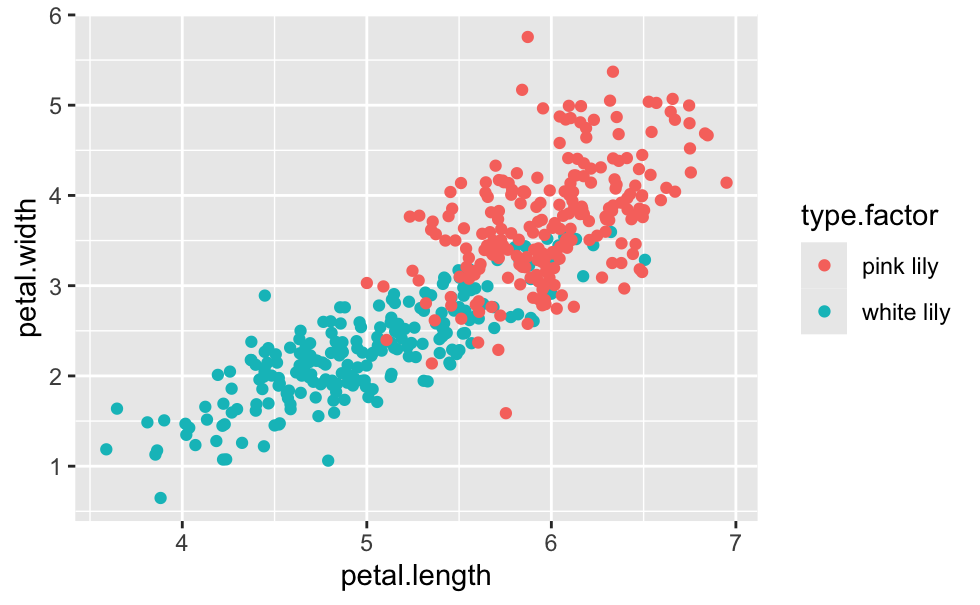

```r
flowers%>%
  ggplot(aes(x=petal.length, y=petal.width, color=type.factor))+
  geom_point()
```

### Part vii

Will it be possible to use these variables to classify the flower type without making errors? Explain your answer.

2 marks

No. there are a few points which are intersected which means that the same length and width appear for both flower types.

## Question 9

We now perform logistic regression to classify the flowers using petal width and petal length as our predictors.

### Part i

Divide the dataset into two dataframes of equal length to create training and test datasets.

Ensure that the split is randomised as the data are ordered by flower type.

2 marks

```r
set.seed(1)
#You might choose to uncomment the line above, to ensure that your split is reproducible -- that every time you divide the data into training and test data you get the same observations in each group.
indice = sample(1:nrow(flowers))
mid = ceiling(nrow(flowers)/2)
train = flowers[indice[1:mid],]
test = flowers[indice[(mid+1):nrow(flowers)],]
```

### Part ii

Perform a logistic regression on the training data to produce a fitted model which can classify the lily type based upon petal width and petal length.

3 marks

```r
model_logred_length = glm(type~petal.length + petal.width,
                          data=train,
                          family=binomial)
summary(model_logred_length)
```

```
Call:
glm(formula = type ~ petal.length + petal.width, family = binomial,
    data = train)

Coefficients:
             Estimate Std. Error z value Pr(>|z|)
(Intercept)   18.2414     3.5232   5.177 2.25e-07 ***
petal.length  -1.5131     0.7053  -2.145   0.0319 *
petal.width   -3.3116     0.6350  -5.215 1.84e-07 ***
---
Signif. codes:  0 ‘***’ 0.001 ‘**’ 0.01 ‘*’ 0.05 ‘.’ 0.1 ‘ ’ 1

(Dispersion parameter for binomial family taken to be 1)

    Null deviance: 318.78  on 229  degrees of freedom
Residual deviance: 116.36  on 227  degrees of freedom
AIC: 122.36

Number of Fisher Scoring iterations: 7
```

```r
train$pred <- predict(model_logred_length,type="resp")
train$pred_type <- if_else(train$pred < 0.5, 0, 1)
```

### Part iii

Make a new column in the test dataframe which stores the flower type predicted by the fit.

2 marks

```r
test$pred <- predict(model_logred_length,type="resp",newdata=test)
test$pred_type <- if_else(test$pred < 0.5, 0, 1)

test$newtype=train$pred_type
```

### Part iv

Create the confusion matrix which shows the result of the classification, in terms of predicted and actual lily types, when applied to the test data.

2 marks

```r
table(predicted=test$pred_type,actual=test$type)
```

```
         actual
predicted   0   1
        0 103  20
        1  10  97
```

### Part v

Calculate the misclassification rate on the test data and on the training data.

3 marks

```r
sum(test$pred_type!= test$type)/nrow(test) *100
```

```
[1] 13.04348
```

### Part vi

Why is measuring the misclassification rate on training data predictions in general not sufficient for testing the performance of our model?

1 mark

A model that overfits will have a low misclassification rate on the training data but a high misclassification rate on new, unseen data. Thus, using the training data to evaluate performance gives an overly optimistic view of the model’s true predictive ability.

## Question 10

We will now use the method of k-nearest neighbours (KNN) to classify the flowers.

### Part i

Create the following dataframes in preparation for performing KNN analysis:

- A dataframe containing all training rows, and columns for petal width and petal length only
- A dataframe containing all training rows, and a factor column of petal type only
- A dataframe containing all test rows, and columns for petal width and petal length only

3 marks

```r
X_train <- data.frame(petal.length = train$petal.length, petal.width= train$petal.width)
Y_train <- data.frame(type = train$type)
X_test <- data.frame(petal.length= test$petal.length,  petal.width= train$petal.width)
```

### Part ii

Carry out KNN analysis using $K=10$ and store the resulting test data predictions.

3 marks

```r
library(class)
Y_train = Y_train$type
Y_test_predicted <- knn(X_train, X_test, Y_train, k=10)
test$type_predicted <- Y_test_predicted
```

### Part iii

Calculate the misclassification rate of the resulting test data predictions.

2 marks

```r
n_incorrect <- sum(test$type != test$type_predicted)
n_correct <- sum(test$type == test$type_predicted)
n_total <- n_correct + n_incorrect
accuracy <- n_incorrect / n_total
accuracy
```

```
[1] 0.4086957
```

### Part iv

Write a loop to repeat the analysis for values of $K$ from 1 to 50, calculating the test data misclassification rate at each step and store these results in a dataframe with columns `K` and `MCR` (mislassification rate).

5 marks

```r
results <- data.frame(K = integer(), MCR = numeric())

# Loop through values of K from 1 to 50
for (k in 1:50) {
  # Predict species using KNN
  Y_pred <- knn(X_train, X_test, Y_train, k = k)

  # Calculate misclassification rate
  misclassified <- sum(Y_pred != test$type)
  mcr <- misclassified / length(test$type)

  # Store the result in the dataframe
  results <- rbind(results, data.frame(K = k, MCR = mcr))
}

# Print the results
print(results)
```

| K | MCR |
| --- | --- |
| 1 | 0.3304348 |
| 2 | 0.3739130 |
| 3 | 0.4043478 |
| 4 | 0.3826087 |
| 5 | 0.4173913 |
| 6 | 0.4086957 |
| 7 | 0.3956522 |
| 8 | 0.3956522 |
| 9 | 0.3869565 |
| 10 | 0.3913043 |

[output cut: 40 more lines]

### Part v

Make a plot of misclassification rate against $K$. Add a horizontal line indicating the best performance over all the values of $K$ you tried. Label your axes appropriately.

3 marks

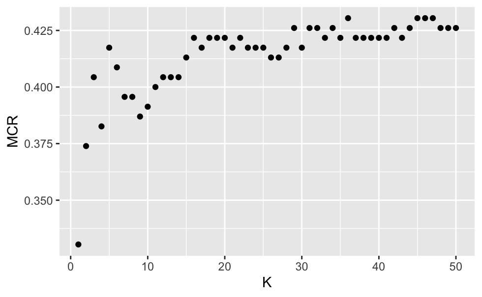

```r
ggplot(results, aes(x=K, y=MCR)) +
  geom_point()
```

# Section A Continued

This question revisits the crab dataset.

## Question 11

### Part i

The file `crabs.csv` can be produced from the file `raw.csv`, which stores only the fundamental crab measurements and presents them in increasing order of body size.

Write code to import `raw.csv` and manipulate it until it contains the same observations as `crabs.csv`, with the same columns, and is also ordered in increasing order of ID.

5 marks

```r
raw_data <- read.csv("raw.csv")
crabs_data <- raw_data %>%
  mutate(
    major.claw = pmax(left.claw, right.claw),
    minor.claw = pmin(left.claw, right.claw),
    claw.ratio = major.claw / minor.claw,
    major.side = ifelse(left.claw > right.claw, "Left", "Right")
  ) %>%
  select(crab.id, body.size, major.claw, minor.claw, claw.ratio, major.side) %>%
  arrange(crab.id)
print(crabs_data)
```

[output not shown]